# Assignment-1

## (h) Where is 10.50 more likely?

Answer: Compare |z| values: whichever is smaller means 10.50 is more typical there. i.e. OLD LOCATION

## (i-l) Boxplots and Outliers

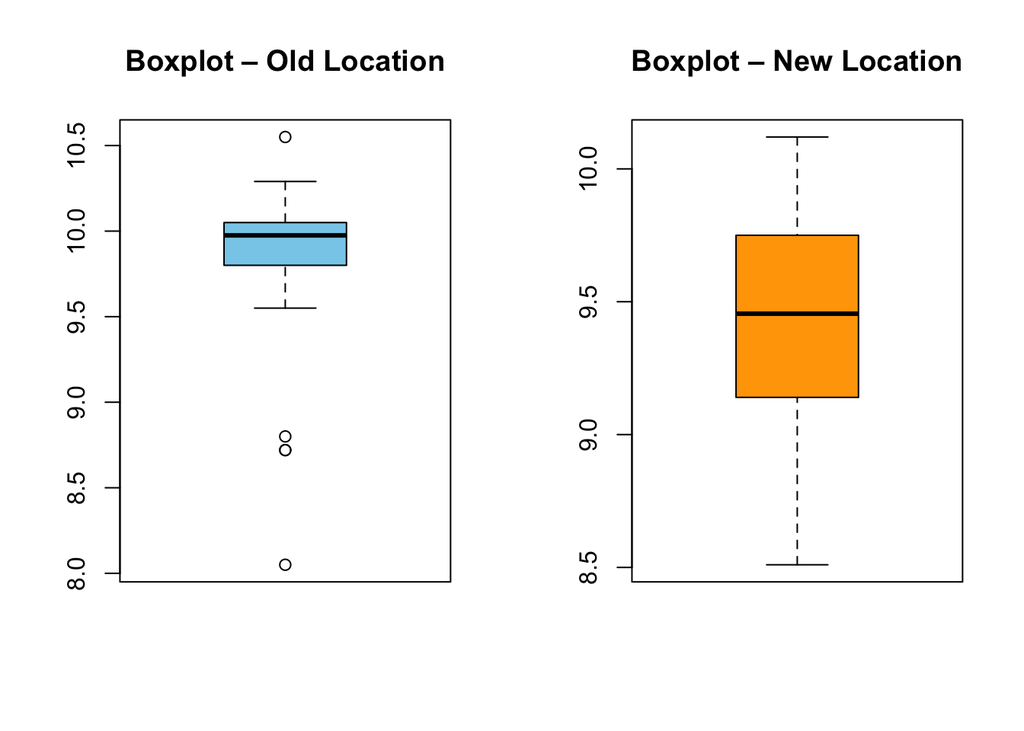

```r
par(mfrow=c(1,2))
boxplot(old, main = "Boxplot – Old Location", col = "skyblue")
boxplot(new, main = "Boxplot – New Location", col = "orange")
```

```r
par(mfrow=c(1,1))

# Outlier detection using z-scores
outliers_old <- old[abs((old - mean_old)/sd(old)) > 2]
outliers_new <- new[abs((new - mean_new)/sd(new)) > 2]
list(OutliersOld = outliers_old, OutliersNew = outliers_new)
```

[output not shown]

## (m) Compare Old vs. New

Answer:

Old readings range lower, with some below the 9.2 threshold.

# Task 12

Data (micrometers) from *Anti-corrosion Methods and Materials* (Vol. 50, 2003).  
Goal: Give an interval that will **likely contain about 95%** of coated pipe roughness measurements.

```r
rough <- c(
  1.72, 2.50, 2.16, 2.13, 1.06, 2.24, 2.31, 2.03, 1.09, 1.40,
  2.57, 2.64, 1.26, 2.05, 1.19, 2.13, 1.27, 1.51, 2.41, 1.95
)

n  <- length(rough)
xbar <- mean(rough)
s <- sd(rough)

# 1) Empirical Rule (Normal-ish): x̄ ± 2s
range_empirical <- c(xbar - 2*s, xbar + 2*s)

# 2) Nonparametric (no distribution assumption): central 95%
range_quantile <- quantile(rough, probs = c(0.025, 0.975), type = 7)

list(
  n = n,
  mean = round(xbar, 3),
  sd = round(s, 3),
  Empirical_95pct_xbar_pm_2s = round(range_empirical, 3),
  Quantile_95pct = round(range_quantile, 3)
)
```

```
## $n
## [1] 20
##
## $mean
## [1] 1.881
##
## $sd
## [1] 0.524
##
## $Empirical_95pct_xbar_pm_2s
## [1] 0.833 2.929
##
## $Quantile_95pct
##  2.5% 97.5%
## 1.074 2.607
```

Interpretation

Both methods suggest that about 95% of pipe roughness values fall between ~1.0 and ~2.9 micrometers.

The empirical rule assumes an approximately normal distribution.

The quantile interval makes no distribution assumption and is narrower.

# Task 13

## Data

```r
# Number of ant species (all 11 sites)
ants_species <- c(3, 3, 52, 7, 5, 49, 5, 4, 56, 22, 14)

# Total plant cover (%)
plant_cover <- c(40, 52, 40, 43, 27, 30, 16, 30, 56, 22, 14)

# Split into regions
dry_species <- ants_species[1:5]
gobi_species <- ants_species[6:11]

dry_cover <- plant_cover[1:5]
gobi_cover <- plant_cover[6:11]
```

## (a) Mean, Median, Mode of Number of Ant Species

```r
mean_species <- mean(ants_species)
median_species <- median(ants_species)
mode_species <- as.numeric(names(which.max(table(ants_species))))

list(Mean = mean_species, Median = median_species, Mode = mode_species)
```

```
## $Mean
## [1] 20
##
## $Median
## [1] 7
##
## $Mode
## [1] 3
```

## (b) Which measure of central tendency?

Answer: Since the data include an extreme outlier (52 species at Site 3), the median is a better measure of central tendency than the mean.

## (c) Dry Steppe Sites – Plant Cover %

```r
list(
  Mean = mean(dry_cover),
  Median = median(dry_cover),
  Mode = as.numeric(names(which.max(table(dry_cover))))
)
```

```
## $Mean
## [1] 40.4
##
## $Median
## [1] 40
##
## $Mode
## [1] 40
```

## (d) Gobi Desert Sites – Plant Cover %

```r
list(
  Mean = mean(gobi_cover),
  Median = median(gobi_cover),
  Mode = as.numeric(names(which.max(table(gobi_cover))))
)
```

```
## $Mean
## [1] 28
##
## $Median
## [1] 26
##
## $Mode
## [1] 30
```

## (e) Compare the Two Regions

Answer: The Dry Steppe has higher plant cover (mean and median) compared to the Gobi Desert. This suggests the two regions have distinct vegetation patterns, which may influence the number of ant species observed.

# Task 14

Astronomers theorize that cold dark matter (CDM) caused the formation of galaxies.  
One galaxy, A1775, is thought to be a *double cluster*. Data from 51 galaxy velocities  
(in km/s) are given below.

```r
# Galaxy velocity data
galaxy <- c(
  22922, 20210, 21911, 19225, 18792, 21993, 23059,
  20785, 22781, 23303, 22192, 19462, 19057, 23017,
  20186, 23292, 19408, 24909, 19866, 22891, 23121,
  19673, 23261, 22796, 22355, 19807, 23432, 22625,
  22744, 22426, 19111, 18933, 22417, 19595, 23408,
  22809, 19619, 22738, 18499, 19130, 23220, 22647,
  22718, 22779, 19026, 22513, 19740, 22682, 19179,
  19404, 22193
)

length(galaxy)
```

```
## [1] 51
```

## (a) Graphical Method

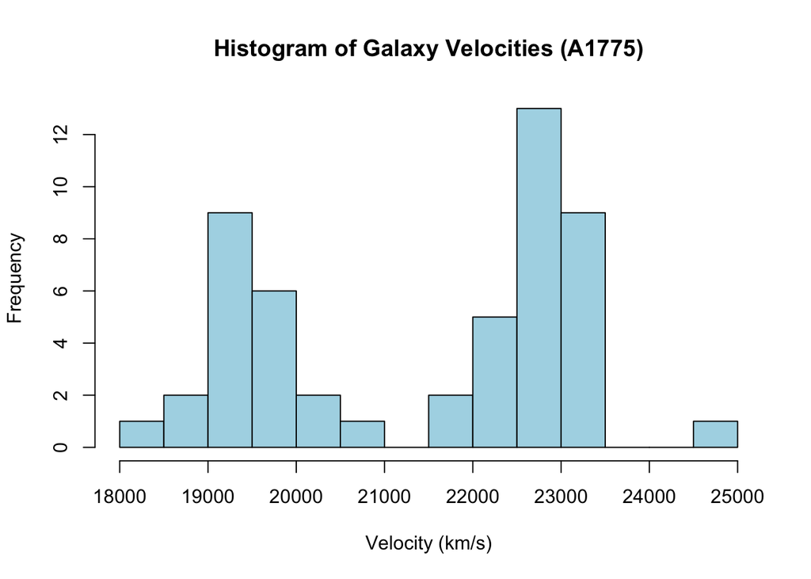

```r
hist(galaxy, breaks=12, col="lightblue", main="Histogram of Galaxy Velocities (A1775)",
     xlab="Velocity (km/s)")
```

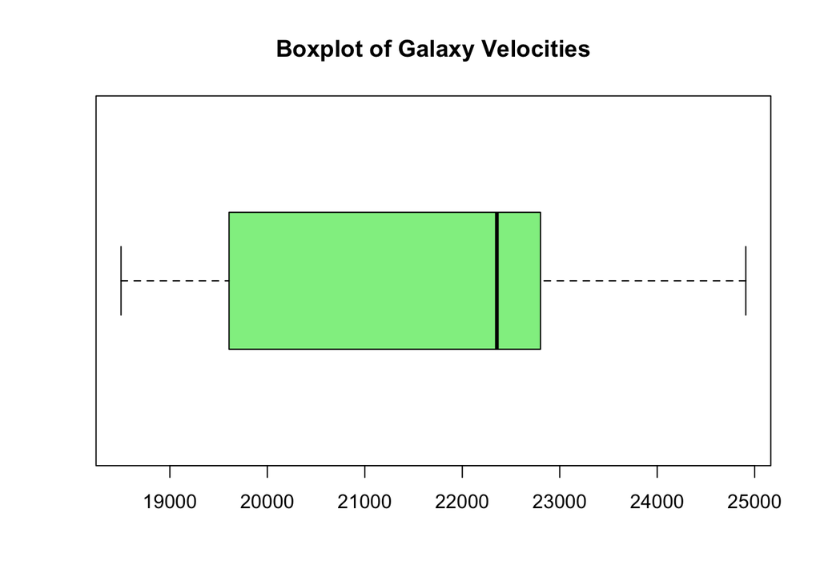

```r
boxplot(galaxy, horizontal=TRUE, col="lightgreen", main="Boxplot of Galaxy Velocities")
```

## (b) Evidence for Double Cluster?

From the histogram/boxplot, we expect to see two peaks (bimodal distribution), which supports the theory of two clusters (A1775A and A1775B).

## (c) Numerical Descriptive Measures

```r
# Overall descriptives
overall <- c(
  n = length(galaxy),
  mean = mean(galaxy),
  sd = sd(galaxy),
  median = median(galaxy),
  min = min(galaxy),
  max = max(galaxy)
)
overall
```

```
##         n      mean        sd    median       min       max
##    51.000 21448.255  1764.103 22355.000 18499.000 24909.000
```

```r
# ---- Discover two clusters automatically (no arbitrary cut) ----
set.seed(42)
km <- kmeans(matrix(galaxy, ncol = 1), centers = 2, nstart = 50)

# Order cluster labels by their means so: A = lower-mean, B = higher-mean
cl_means <- tapply(galaxy, km$cluster, mean)
ord <- order(cl_means)                # index of lower, higher
# Relabel to A/B
clusterAB <- ifelse(km$cluster == which(ord == 1), "A1775A", "A1775B")

# Descriptives by cluster
by_mean <- tapply(galaxy, clusterAB, mean)
by_sd   <- tapply(galaxy, clusterAB, sd)
by_n    <- tapply(galaxy, clusterAB, length)
by_sum  <- rbind(n = by_n, mean = by_mean, sd = by_sd)
round(by_sum, 2)
```

```
##        A1775A   A1775B
## n       21.00    30.00
## mean 19462.24 22838.47
## sd     532.29   560.98
```

#Visual check

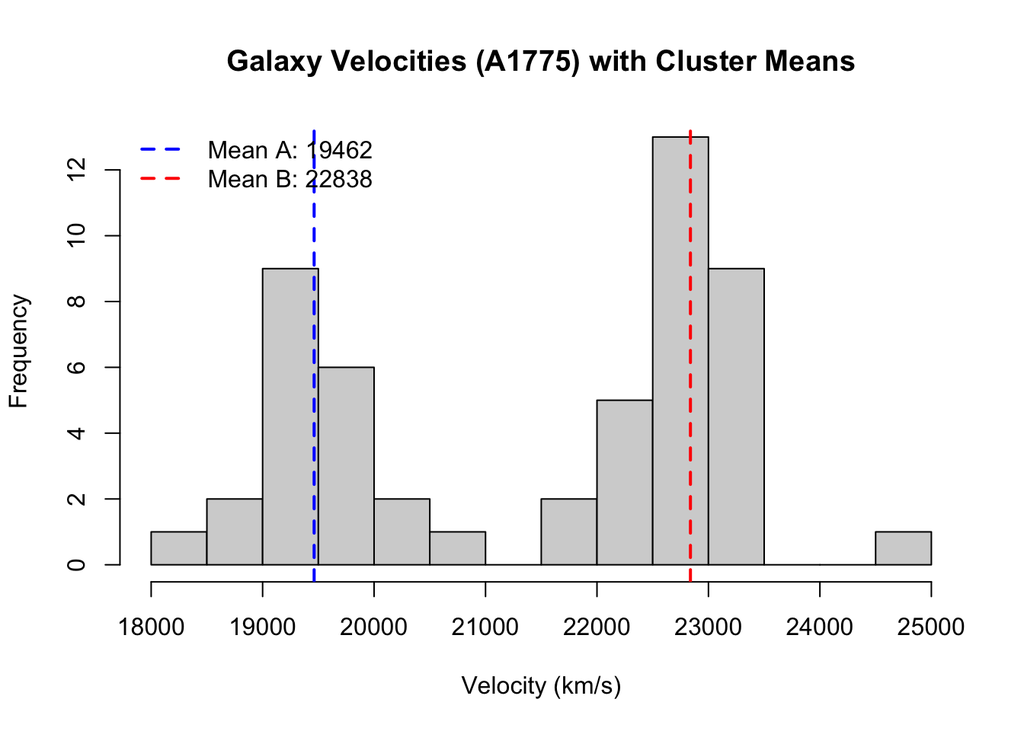

```r
hist(galaxy, breaks = 12, col = "lightgray",
     main = "Galaxy Velocities (A1775) with Cluster Means",
     xlab = "Velocity (km/s)")
abline(v = by_mean["A1775A"], col = "blue",  lwd = 2, lty = 2)
abline(v = by_mean["A1775B"], col = "red",   lwd = 2, lty = 2)
legend("topleft",
       legend = c(paste0("Mean A: ", round(by_mean["A1775A"],0)),
                  paste0("Mean B: ", round(by_mean["A1775B"],0))),
       col = c("blue","red"), lwd = 2, lty = 2, bty = "n")
```

## (d) Probability of 20,000 km/s Galaxy

```r
x0 <- 20000

muA <- by_mean["A1775A"]; sdA <- by_sd["A1775A"]; nA <- by_n["A1775A"]
muB <- by_mean["A1775B"]; sdB <- by_sd["A1775B"]; nB <- by_n["A1775B"]
piA <- nA / (nA + nB);     piB <- nB / (nA + nB)

# 1) Z-scores
zA <- (x0 - muA)/sdA
zB <- (x0 - muB)/sdB

# 2) Posterior via normal densities with mixing proportions
likA <- piA * dnorm(x0, mean = muA, sd = sdA)
likB <- piB * dnorm(x0, mean = muB, sd = sdB)
postA <- likA / (likA + likB)
postB <- 1 - postA

list(
  z_in_A = round(zA, 2),
  z_in_B = round(zB, 2),
  posterior_P_A = round(postA, 3),
  posterior_P_B = round(postB, 3)
)
```

```
## $z_in_A
## A1775A
##   1.01
##
## $z_in_B
## A1775B
##  -5.06
##
## $posterior_P_A
## A1775A
##      1
##
## $posterior_P_B
## A1775A
##      0
```

```r
best_cluster <- if (postA >= postB) "A1775A" else "A1775B"
best_cluster
```

```
## [1] "A1775A"
```

# Task 15

```r
# Load required packages
library(ggplot2)

# Read the dataset (adjust the path if needed)
ddt <- read.csv("DDT.csv", header = TRUE)

# Preview the structure of the data
head(ddt)
```

```
##   RIVER MILE  SPECIES LENGTH WEIGHT DDT
## 1   FCM    5 CCATFISH   42.5    732  10
## 2   FCM    5 CCATFISH   44.0    795  16
## 3   FCM    5 CCATFISH   41.5    547  23
## 4   FCM    5 CCATFISH   39.0    465  21
## 5   FCM    5 CCATFISH   50.5   1252  50
## 6   FCM    5 CCATFISH   52.0   1255 150
```

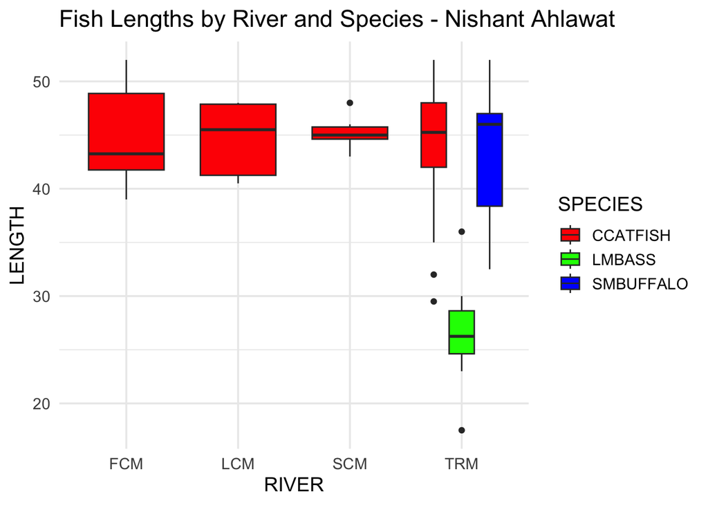

```r
# Create the boxplot
ggplot(ddt, aes(x=RIVER, y=LENGTH, fill=SPECIES)) +
  geom_boxplot() +
  scale_fill_manual(values = c("CCATFISH" = "red",
                               "LMBASS"   = "green",
                               "SMBUFFALO"= "blue")) +
  labs(title = "Fish Lengths by River and Species - Nishant Ahlawat",
       x = "RIVER",
       y = "LENGTH",
       fill = "SPECIES") +
  theme_minimal(base_size = 14)
```